# Pertemuan 3 - Regresi dengan Peubah Lag

## Impor Data

```r
data <- rio::import("https://raw.githubusercontent.com/rizkynurhambali/praktikum-sta1341/main/Pertemuan%203/Data%20Asli.csv")
str(data)
```

```
## 'data.frame':    20 obs. of  4 variables:
##  $ t     : int  1 2 3 4 5 6 7 8 9 10 ...
##  $ Yt    : num  52.9 53.8 54.9 58.2 60 63.4 68.2 78 84.7 90.6 ...
##  $ Y(t-1): num  NA 52.9 53.8 54.9 58.2 60 63.4 68.2 78 84.7 ...
##  $ Xt    : num  30.3 30.9 30.9 33.4 35.1 37.3 41 44.9 46.5 50.3 ...
```

```r
data
```

```
##     t    Yt Y(t-1)    Xt
## 1   1  52.9     NA  30.3
## 2   2  53.8   52.9  30.9
## 3   3  54.9   53.8  30.9
## 4   4  58.2   54.9  33.4
## 5   5  60.0   58.2  35.1
## 6   6  63.4   60.0  37.3
## 7   7  68.2   63.4  41.0
## 8   8  78.0   68.2  44.9
## 9   9  84.7   78.0  46.5
## 10 10  90.6   84.7  50.3
## 11 11  98.2   90.6  53.5
## 12 12 101.7   98.2  52.8
## 13 13 102.7  101.7  55.9
## 14 14 108.3  102.7  63.0
## 15 15 124.7  108.3  73.0
## 16 16 157.9  124.7  84.8
## 17 17 158.2  157.9  86.6
## 18 18 170.2  158.2  98.9
## 19 19 180.0  170.2 110.8
## 20 20 198.0  180.0 124.7
```

## Pembagian Data

```r
#SPLIT DATA
train<-data[1:15,]
test<-data[16:20,]
```

```r
#data time series
train.ts<-ts(train)
test.ts<-ts(test)
data.ts<-ts(data)
```

[figure not shown]

- **distributed lag model** : Variabel Dependen Y dipengaruhi oleh lag dari variabel independen X ( Xt-1, Xt-2 , dst)
- **Autoregresive model** : Variabel Dependen Y dipengaruhi oleh lag dirinya sendiri (Yt-1, Yt-2, dst) dan X sekarang (Xt)

## Model Koyck

Model Koyck didasarkan pada asumsi bahwa semakin jauh jarak lag peubah independen dari periode sekarang maka semakin kecil pengaruh peubah lag terhadap peubah dependen.

Koyck mengusulkan suatu metode untuk menduga model dinamis distributed lag dengan mengasumsikan bahwa semua koefisien $\beta$ mempunyai tanda sama.

Model kyock merupakan jenis paling umum dari model infinite distributed lag dan juga dikenal sebagai geometric lag

$$y_t=a(1-\lambda)+\beta_0X_t+\beta_1Z_t+\lambda Y_{t-1}+V_t$$

dengan
$$V_t=u_t-\lambda
u_{t-1}$$

### Pemodelan

Pemodelan model Koyck dengan `R` dapat menggunakan `dLagM::koyckDlm()` . Fungsi umum dari `koyckDlm` adalah sebagai berikut.

```r
koyckDlm(x , y , intercept)
```

Fungsi `koyckDlm()` akan menerapkan model lag terdistribusi dengan transformasi Koyck satu prediktor. Nilai `x` dan `y` tidak perlu sebagai objek *time series* (`ts`). `intercept` dapat dibuat `TRUE` untuk memasukkan intersep ke dalam model.

```r
#MODEL KOYCK
model.koyck <- koyckDlm(x = train$Xt, y = train$Yt)
summary(model.koyck)
```

```
##
## Call:
## "Y ~ (Intercept) + Y.1 + X.t"
##
## Residuals:
##      Min       1Q   Median       3Q      Max
## -3.75605 -1.16407  0.01599  1.17295  3.28003
##
## Coefficients:
##             Estimate Std. Error t value Pr(>|t|)
## (Intercept)  -3.7335     2.1785  -1.714   0.1146
## Y.1           0.4214     0.1158   3.639   0.0039 **
## X.t           1.1510     0.1901   6.055 8.25e-05 ***
## ---
## Signif. codes:  0 '***' 0.001 '**' 0.01 '*' 0.05 '.' 0.1 ' ' 1
##
## Residual standard error: 2.023 on 11 degrees of freedom
## Multiple R-Squared: 0.9934,  Adjusted R-squared: 0.9922
## Wald test: 828.9 on 2 and 11 DF,  p-value: 1.01e-12
##
## Diagnostic tests:
## NULL
##
##                              alpha     beta       phi
## Geometric coefficients:  -6.452844 1.150951 0.4214181
```

```r
AIC(model.koyck)
```

```
## [1] 64.08525
```

```r
BIC(model.koyck)
```

```
## [1] 66.64148
```

Dari hasil tersebut, didapat bahwa peubah $x_t$ dan $y_{t-1}$ memiliki nilai $P-Value<0.05$. Hal ini menunjukkan bahwa peubah $x_t$ dan $y_{t-1}$ berpengaruh signifikan terhadap $y$. Adapun model keseluruhannya adalah sebagai berikut

$$\hat{Y_t}=-3.7335+1.1510X_t+0.4214Y_{t-1}$$

### Peramalan dan Akurasi

Berikut adalah hasil peramalan y untuk 5 periode kedepan menggunakan model koyck

```r
fore.koyck <- forecast(model = model.koyck, x=test$Xt, h=5)
fore.koyck
```

```
## $forecasts
## [1] 146.4180 157.6420 176.5288 198.1843 223.3085
##
## $call
## forecast.koyckDlm(model = model.koyck, x = test$Xt, h = 5)
##
## attr(,"class")
## [1] "forecast.koyckDlm" "dLagM"
```

```r
mape.koyck <- MAPE(fore.koyck$forecasts, test$Yt)
mape.koyck #data test
```

```
## [1] 0.06845456
```

```r
#akurasi data training
GoF(model.koyck)
```

```
##              n      MAE           MPE       MAPE      sMAPE      MASE      MSE
## model.koyck 14 1.473599 -0.0004874002 0.01720083 0.01719063 0.2701945 3.216237
##                  MRAE     GMRAE
## model.koyck 0.3967354 0.3026997
```

## Regression with Distributed Lag

Pemodelan model Regression with Distributed Lag dengan `R` dapat menggunakan `dLagM::dlm()` . Fungsi umum dari `dlm` adalah sebagai berikut.

```r
dlm(formula , data , x , y , q , remove )
```

Fungsi `dlm()` akan menerapkan model lag terdistribusi dengan satu atau lebih prediktor. Nilai `x` dan `y` tidak perlu sebagai objek *time series* (`ts`). $q$ adalah integer yang mewakili panjang *lag* yang terbatas.

### Pemodelan (Lag=2)

```r
model.dlm <- dlm(x = train$Xt,y = train$Yt , q = 2)
summary(model.dlm)
```

```
##
## Call:
## lm(formula = model.formula, data = design)
##
## Residuals:
##     Min      1Q  Median      3Q     Max
## -1.4446 -0.6965 -0.2373  0.8810  1.8630
##
## Coefficients:
##             Estimate Std. Error t value Pr(>|t|)
## (Intercept)  -9.6779     1.8156  -5.330 0.000474 ***
## x.t           0.3179     0.1792   1.774 0.109856
## x.1           1.5276     0.3487   4.380 0.001770 **
## x.2           0.2651     0.2440   1.087 0.305388
## ---
## Signif. codes:  0 '***' 0.001 '**' 0.01 '*' 0.05 '.' 0.1 ' ' 1
##
## Residual standard error: 1.322 on 9 degrees of freedom
## Multiple R-squared:  0.9974, Adjusted R-squared:  0.9965
## F-statistic:  1133 on 3 and 9 DF,  p-value: 6.471e-12
##
## AIC and BIC values for the model:
##       AIC      BIC
## 1 49.3705 52.19525
```

```r
AIC(model.dlm)
```

```
## [1] 49.3705
```

```r
BIC(model.dlm)
```

```
## [1] 52.19525
```

Dari hasil diatas, didapat bahwa $P-value$ dari intercept dan $x_{t-1}<0.05$. Hal ini menunjukkan bahwa intercept dan $x_{t-1}$ berpengaruh signifikan terhadap $y$. Adapun model keseluruhan yang terbentuk adalah sebagai berikut

$$\hat{Y_t}=-9.6779+0.3179X_t+1.5276X_{t-1}+0.2651X_{t-2}$$

### Peramalan dan Akurasi

Berikut merupakan hasil peramalan $y$ untuk 5 periode kedepan

```r
fore.dlm <- forecast(model = model.dlm, x=test$Xt, h=5)
fore.dlm
```

```
## $forecasts
## [1] 145.5021 166.7516 176.5405 199.5907 225.4498
##
## $call
## forecast.dlm(model = model.dlm, x = test$Xt, h = 5)
##
## attr(,"class")
## [1] "forecast.dlm" "dLagM"
```

```r
mape.dlm <- MAPE(fore.dlm$forecasts, test$Yt)
mape.dlm
```

```
## [1] 0.08345978
```

```r
#akurasi data training
GoF(model.dlm)
```

```
##            n       MAE           MPE       MAPE      sMAPE      MASE      MSE
## model.dlm 13 0.9282513 -0.0002879026 0.01227837 0.01229574 0.1595847 1.210003
##                MRAE     GMRAE
## model.dlm 0.2350414 0.1491444
```

### *Lag* Optimum

```r
#penentuan lag optimum
finiteDLMauto(formula = Yt ~ Xt,
              data = data.frame(train), q.min = 1, q.max = 10,
              model.type = "dlm", error.type = "AIC", trace = TRUE)
```

```
##    q - k    MASE       AIC       BIC   GMRAE    MBRAE R.Adj.Sq   Ljung-Box
## 7      7 0.00000      -Inf      -Inf 0.00000  0.00000      NaN         NaN
## 8      8 0.00000      -Inf      -Inf 0.00000  0.00000      NaN         NaN
## 9      9 0.00000      -Inf      -Inf 0.00000  0.00000      NaN         NaN
## 10    10 0.00000      -Inf      -Inf 0.00000  0.00000      NaN         NaN
## 6      6 0.00214 -29.87368 -28.09865 0.00225  0.00125  0.99999 0.983064249
## 5      5 0.05106  26.22283  28.64351 0.05362  0.00407  0.99848 0.008718525
## 4      4 0.09175  37.32725  40.11252 0.07960 -0.03335  0.99741 0.136398279
## 3      3 0.14898  48.42255  51.33199 0.09585 -0.20490  0.99543 0.524105756
## 2      2 0.15958  49.37050  52.19525 0.14914 -0.13532  0.99648 0.738616442
## 1      1 0.17862  51.20728  53.76351 0.20782 -0.14048  0.99688 0.801604351
```

Berdasarkan output tersebut, lag optimum didapatkan ketika lag=6. Selanjutnya dilakukan pemodelan untuk lag=6

```r
#model dlm dengan lag optimum
model.dlm2 <- dlm(x = train$Xt,y = train$Yt , q = 6)
summary(model.dlm2)
```

```
##
## Call:
## lm(formula = model.formula, data = design)
##
## Residuals:
##         1         2         3         4         5         6         7         8
## -0.023415  0.014375  0.032641 -0.010695 -0.013096 -0.014927  0.010054  0.010809
##         9
## -0.005747
##
## Coefficients:
##             Estimate Std. Error t value Pr(>|t|)
## (Intercept) 21.42223    1.44472  14.828   0.0429 *
## x.t          1.68749    0.04758  35.466   0.0179 *
## x.1         -1.23901    0.11688 -10.600   0.0599 .
## x.2          0.97604    0.02787  35.021   0.0182 *
## x.3         -0.23945    0.02746  -8.719   0.0727 .
## x.4          3.24431    0.14678  22.103   0.0288 *
## x.5          0.08560    0.04903   1.746   0.3312
## x.6         -3.47612    0.15157 -22.933   0.0277 *
## ---
## Signif. codes:  0 '***' 0.001 '**' 0.01 '*' 0.05 '.' 0.1 ' ' 1
##
## Residual standard error: 0.05079 on 1 degrees of freedom
## Multiple R-squared:      1,  Adjusted R-squared:      1
## F-statistic: 1.277e+05 on 7 and 1 DF,  p-value: 0.002155
##
## AIC and BIC values for the model:
##         AIC       BIC
## 1 -29.87368 -28.09865
```

```r
AIC(model.dlm2)
```

```
## [1] -29.87368
```

```r
BIC(model.dlm2)
```

```
## [1] -28.09865
```

Dari hasil tersebut terdapat beberapa peubah yang berpengaruh signifikan terhadap taraf nyata 5% yaitu $x_t$ , $x_{t-2}$ , $x_{t-4}$ , $x_{t-6}$. Adapun keseluruhan model yang terbentuk adalah

$$\hat{Y_t}=21.42223+1.68749X_t+...-3.47612X_{t-6}$$

Adapun hasil peramalan 5 periode kedepan menggunakan model tersebut adalah sebagai berikut

```r
#peramalan dan akurasi
fore.dlm2 <- forecast(model = model.dlm2, x=test$Xt, h=5)

#akurasi data test
mape.dlm2<- MAPE(fore.dlm2$forecasts, test$Yt)
mape.dlm2
```

```
## [1] 0.1511753
```

```r
#akurasi data training
GoF(model.dlm2)
```

```
##            n        MAE           MPE         MAPE        sMAPE        MASE
## model.dlm2 9 0.01508446 -2.246354e-06 0.0001727757 0.0001727773 0.002135853
##                     MSE        MRAE       GMRAE
## model.dlm2 0.0002866713 0.003309313 0.002245928
```

## Model Autoregressive

Peubah dependen dipengaruhi oleh peubah independen pada waktu sekarang, serta dipengaruhi juga oleh peubah dependen itu sendiri pada satu waktu yang lalu maka model tersebut disebut *autoregressive* (Gujarati 2004).

### Pemodelan

Pemodelan Autoregressive dilakukan menggunakan fungsi `dLagM::ardlDlm()` . Fungsi tersebut akan menerapkan *autoregressive* berordo $(p,q)$ dengan satu prediktor. Fungsi umum dari `ardlDlm()` adalah sebagai berikut.

```r
ardlDlm(formula = NULL , data = NULL , x = NULL , y = NULL , p = 1 , q = 1 ,
         remove = NULL )
```

Dengan $p$ adalah integer yang mewakili panjang *lag* yang terbatas dan $q$ adalah integer yang merepresentasikan ordo dari proses *autoregressive*.

```r
model.ardl <- ardlDlm(x = train$Xt, y = train$Yt, p = 1 , q = 1)
summary(model.ardl)
```

```
##
## Time series regression with "ts" data:
## Start = 2, End = 15
##
## Call:
## dynlm(formula = as.formula(model.text), data = data, start = 1)
##
## Residuals:
##     Min      1Q  Median      3Q     Max
## -1.6274 -0.8401 -0.1767  0.8392  1.9447
##
## Coefficients:
##             Estimate Std. Error t value Pr(>|t|)
## (Intercept)  -8.3594     1.9186  -4.357  0.00143 **
## X.t           0.3563     0.1875   1.900  0.08661 .
## X.1           1.4557     0.4071   3.575  0.00505 **
## Y.1           0.1408     0.1318   1.068  0.31055
## ---
## Signif. codes:  0 '***' 0.001 '**' 0.01 '*' 0.05 '.' 0.1 ' ' 1
##
## Residual standard error: 1.269 on 10 degrees of freedom
## Multiple R-squared:  0.9976, Adjusted R-squared:  0.9969
## F-statistic:  1405 on 3 and 10 DF,  p-value: 2.006e-13
```

```r
AIC(model.ardl)
```

```
## [1] 51.69462
```

```r
BIC(model.ardl)
```

```
## [1] 54.8899
```

```r
model.ardl <- ardlDlm(formula = Yt ~ Xt,
                         data = train,p = 1 , q = 1)
summary(model.ardl)
```

```
##
## Time series regression with "ts" data:
## Start = 2, End = 15
##
## Call:
## dynlm(formula = as.formula(model.text), data = data)
##
## Residuals:
##     Min      1Q  Median      3Q     Max
## -1.6274 -0.8401 -0.1767  0.8392  1.9447
##
## Coefficients:
##             Estimate Std. Error t value Pr(>|t|)
## (Intercept)  -8.3594     1.9186  -4.357  0.00143 **
## Xt.t          0.3563     0.1875   1.900  0.08661 .
## Xt.1          1.4557     0.4071   3.575  0.00505 **
## Yt.1          0.1408     0.1318   1.068  0.31055
## ---
## Signif. codes:  0 '***' 0.001 '**' 0.01 '*' 0.05 '.' 0.1 ' ' 1
##
## Residual standard error: 1.269 on 10 degrees of freedom
## Multiple R-squared:  0.9976, Adjusted R-squared:  0.9969
## F-statistic:  1405 on 3 and 10 DF,  p-value: 2.006e-13
```

```r
AIC(model.ardl)
```

```
## [1] 51.69462
```

```r
BIC(model.ardl)
```

```
## [1] 54.8899
```

$$\hat{Y}=-8,3594+0,3563X_t+1,4557X_{t-1}+0,1408Y_{t-1}$$

### Peramalan dan Akurasi

```r
fore.ardl <- forecast(model = model.ardl, x=test$Xt, h=5)
fore.ardl
```

```
## $forecasts
## [1] 145.6865 166.4608 176.3897 199.9337 225.5255
##
## $call
## forecast.ardlDlm(model = model.ardl, x = test$Xt, h = 5)
##
## attr(,"class")
## [1] "forecast.ardlDlm" "dLagM"
```

Data di atas merupakan hasil peramalan untuk 5 periode ke depan menggunakan Model Autoregressive dengan $p=1$ dan $q=1$.

```r
mape.ardl <- MAPE(fore.ardl$forecasts, test$Yt)
mape.ardl
```

```
## [1] 0.08313896
```

```r
#akurasi data training
GoF(model.ardl)
```

```
##             n       MAE           MPE       MAPE      sMAPE      MASE     MSE
## model.ardl 14 0.8821232 -0.0003216464 0.01183235 0.01185341 0.1617433 1.15063
##                 MRAE     GMRAE
## model.ardl 0.2332582 0.1391987
```

### *Lag* Optimum

```r
#penentuan lag optimum
model.ardl.opt <- ardlBoundOrders(data = data.frame(data), ic = "AIC",
                                  formula = Yt ~ Xt )
model.ardl.opt
```

```
## $p
##   Xt
## 1  6
##
## $q
## [1] 1
##
## $Stat.table
##           q = 1     q = 2     q = 3     q = 4    q = 5    q = 6 q = 7 q = 8
## p = 1 112.18269 109.52534 105.52217 101.63734 95.28841 88.62221    NA    NA
## p = 2 107.53473 107.27801 104.24754  98.64030 82.80884 78.24396    NA    NA
## p = 3 104.39360 104.39360 106.01978  99.61104 80.50702       NA    NA    NA
## p = 4  96.84811  96.30318  96.30318  92.11385 81.60323       NA    NA    NA
## p = 5  86.53889  84.38162  71.12124  71.12124       NA       NA    NA    NA
## p = 6 -20.56587        NA        NA        NA       NA       NA    NA    NA
##       q = 9 q = 10 q = 11 q = 12 q = 13 q = 14 q = 15
## p = 1    NA     NA     NA     NA     NA     NA     NA
## p = 2    NA     NA     NA     NA     NA     NA     NA
## p = 3    NA     NA     NA     NA     NA     NA     NA
## p = 4    NA     NA     NA     NA     NA     NA     NA
## p = 5    NA     NA     NA     NA     NA     NA     NA
## p = 6    NA     NA     NA     NA     NA     NA     NA
##
## $min.Stat
## [1] -20.56587
```

```r
min_p=c()
for(i in 1:6){
  min_p[i]=min(model.ardl.opt$Stat.table[[i]])
}
q_opt=which(min_p==min(min_p, na.rm = TRUE))
p_opt=which(model.ardl.opt$Stat.table[[q_opt]] ==
              min(model.ardl.opt$Stat.table[[q_opt]], na.rm = TRUE))
data.frame("q_optimum" = q_opt, "p_optimum" = p_opt,
           "AIC"=model.ardl.opt$min.Stat)
```

```
##   q_optimum p_optimum       AIC
## 1         1         6 -20.56587
```

Dari tabel di atas, dapat terlihat bahwa nilai AIC terendah didapat ketika $p=6$ dan $q=1$, yaitu sebesar `-20,56587`. Artinya, model autoregressive optimum didapat ketika $p=6$ dan $q=1$.

Selanjutnya dapat dilakukan pemodelan dengan nilai $p$ dan $q$ optimum seperti inisialisasi di langkah sebelumnya.

## Pemodelan DLM & ARDL dengan Library `dynlm`

Pemodelan regresi dengan peubah *lag* tidak hanya dapat dilakukan dengan fungsi pada *packages* `dLagM` , tetapi terdapat *packages* `dynlm` yang dapat digunakan. Fungsi `dynlm` secara umum adalah sebagai berikut.

```r
dynlm(formula, data, subset, weights, na.action, method = "qr",
  model = TRUE, x = FALSE, y = FALSE, qr = TRUE, singular.ok = TRUE,
  contrasts = NULL, offset, start = NULL, end = NULL, ...)
```

Untuk menentukan `formula` model yang akan digunakan, tersedia fungsi tambahan yang memungkinkan spesifikasi dinamika (melalui `d()` dan `L()`) atau pola linier/siklus dengan mudah (melalui `trend()`, `season()`, dan `harmon()`). Semua fungsi formula baru mengharuskan argumennya berupa objek deret waktu (yaitu, `"ts"` atau `"zoo"`).

`L()` : fungsi untuk mengambil nilai lag dari suatu variabel.

`L(Xt)`= Xt pada periode sebelumnya (lag ke-1).

`L(Xt, 2)` = Xt pada dua periode sebelumnya (lag ke-2).

```r
#sama dengan model dlm q=1
cons_lm1 <- dynlm(Yt ~ Xt+L(Xt),data = train.ts)

#sama dengan model ardl p=1 q=0
cons_lm2 <- dynlm(Yt ~ Xt+L(Yt),data = train.ts)

#sama dengan ardl p=1 q=1
cons_lm3 <- dynlm(Yt ~ Xt+L(Xt)+L(Yt),data = train.ts)

#sama dengan dlm p=2
cons_lm4 <- dynlm(Yt ~ Xt+L(Xt)+L(Xt,2),data = train.ts)
```

### Ringkasan Model

Berikut adalah ringkasan hasil estimasi dari masing-masing model:

```r
summary(cons_lm1)
```

```
##
## Time series regression with "ts" data:
## Start = 2, End = 15
##
## Call:
## dynlm(formula = Yt ~ Xt + L(Xt), data = train.ts)
##
## Residuals:
##     Min      1Q  Median      3Q     Max
## -1.4118 -0.8790 -0.3542  0.7202  2.3047
##
## Coefficients:
##             Estimate Std. Error t value Pr(>|t|)
## (Intercept)  -9.4870     1.6123  -5.884 0.000106 ***
## Xt            0.2557     0.1632   1.567 0.145434
## L(Xt)         1.8395     0.1927   9.547 1.17e-06 ***
## ---
## Signif. codes:  0 '***' 0.001 '**' 0.01 '*' 0.05 '.' 0.1 ' ' 1
##
## Residual standard error: 1.277 on 11 degrees of freedom
## Multiple R-squared:  0.9974, Adjusted R-squared:  0.9969
## F-statistic:  2081 on 2 and 11 DF,  p-value: 6.538e-15
```

```r
summary(cons_lm2)
```

```
##
## Time series regression with "ts" data:
## Start = 2, End = 15
##
## Call:
## dynlm(formula = Yt ~ Xt + L(Yt), data = train.ts)
##
## Residuals:
##     Min      1Q  Median      3Q     Max
## -3.4441 -1.1436  0.1785  1.5549  2.1584
##
## Coefficients:
##             Estimate Std. Error t value Pr(>|t|)
## (Intercept) -3.54096    1.96526  -1.802    0.099 .
## Xt           0.92218    0.14482   6.368 5.31e-05 ***
## L(Yt)        0.55684    0.08922   6.241 6.34e-05 ***
## ---
## Signif. codes:  0 '***' 0.001 '**' 0.01 '*' 0.05 '.' 0.1 ' ' 1
##
## Residual standard error: 1.827 on 11 degrees of freedom
## Multiple R-squared:  0.9946, Adjusted R-squared:  0.9936
## F-statistic:  1015 on 2 and 11 DF,  p-value: 3.344e-13
```

```r
summary(cons_lm3)
```

```
##
## Time series regression with "ts" data:
## Start = 2, End = 15
##
## Call:
## dynlm(formula = Yt ~ Xt + L(Xt) + L(Yt), data = train.ts)
##
## Residuals:
##     Min      1Q  Median      3Q     Max
## -1.6274 -0.8401 -0.1767  0.8392  1.9447
##
## Coefficients:
##             Estimate Std. Error t value Pr(>|t|)
## (Intercept)  -8.3594     1.9186  -4.357  0.00143 **
## Xt            0.3563     0.1875   1.900  0.08661 .
## L(Xt)         1.4557     0.4071   3.575  0.00505 **
## L(Yt)         0.1408     0.1318   1.068  0.31055
## ---
## Signif. codes:  0 '***' 0.001 '**' 0.01 '*' 0.05 '.' 0.1 ' ' 1
##
## Residual standard error: 1.269 on 10 degrees of freedom
## Multiple R-squared:  0.9976, Adjusted R-squared:  0.9969
## F-statistic:  1405 on 3 and 10 DF,  p-value: 2.006e-13
```

```r
summary(cons_lm4)
```

```
##
## Time series regression with "ts" data:
## Start = 3, End = 15
##
## Call:
## dynlm(formula = Yt ~ Xt + L(Xt) + L(Xt, 2), data = train.ts)
##
## Residuals:
##     Min      1Q  Median      3Q     Max
## -1.4446 -0.6965 -0.2373  0.8810  1.8630
##
## Coefficients:
##             Estimate Std. Error t value Pr(>|t|)
## (Intercept)  -9.6779     1.8156  -5.330 0.000474 ***
## Xt            0.3179     0.1792   1.774 0.109856
## L(Xt)         1.5276     0.3487   4.380 0.001770 **
## L(Xt, 2)      0.2651     0.2440   1.087 0.305388
## ---
## Signif. codes:  0 '***' 0.001 '**' 0.01 '*' 0.05 '.' 0.1 ' ' 1
##
## Residual standard error: 1.322 on 9 degrees of freedom
## Multiple R-squared:  0.9974, Adjusted R-squared:  0.9965
## F-statistic:  1133 on 3 and 9 DF,  p-value: 6.471e-12
```

### SSE

Selain ringkasan hasil, kita juga bisa menghitung nilai SSE dari masing-masing model.

```r
deviance(cons_lm1)
```

```
## [1] 17.94685
```

```r
deviance(cons_lm2)
```

```
## [1] 36.70155
```

```r
deviance(cons_lm3)
```

```
## [1] 16.10882
```

```r
deviance(cons_lm4)
```

```
## [1] 15.73004
```

Semakin kecil nilai SSE, berarti model lebih baik dalam menyesuaikan data (karena error lebih kecil).

### Ui encomptest

langkah selanjutnya adalah membandingkan kinerja antar model. selanjutnya adalah membandingkan kinerja antar model. Salah satu pendekatan yang dapat digunakan adalah encompassing test dengan fungsi `encomptest()` dari package `lmtest`.

```r
#uji model
if(require("lmtest")) encomptest(cons_lm1, cons_lm2)
```

```
## Encompassing test
##
## Model 1: Yt ~ Xt + L(Xt)
## Model 2: Yt ~ Xt + L(Yt)
## Model E: Yt ~ Xt + L(Xt) + L(Yt)
##           Res.Df Df      F  Pr(>F)
## M1 vs. ME     10 -1  1.141 0.31055
## M2 vs. ME     10 -1 12.784 0.00505 **
## ---
## Signif. codes:  0 '***' 0.001 '**' 0.01 '*' 0.05 '.' 0.1 ' ' 1
```

- Model 1 : p-value 0.31055 (> 0.05). Artinya, penambahan lag dari Y (`L(Yt)`) tidak memberikan peningkatan signifikan.  
  Dengan demikian, Model 1 sudah memadai.
- Model 2 : p-value = 0.00505 (< 0.01).  
  Artinya, penambahan lag dari X (`L(Xt)`) memberikan peningkatan signifikan.Sehingga Model 2 tidak cukup memadai tanpa tambahan variabel lag dari Xt.

#### Uji Autokorelasi Residual

```r
#durbin watson
dwtest(cons_lm1)
```

```
##
##  Durbin-Watson test
##
## data:  cons_lm1
## DW = 2.1065, p-value = 0.3842
## alternative hypothesis: true autocorrelation is greater than 0
```

```r
dwtest(cons_lm2)
```

```
##
##  Durbin-Watson test
##
## data:  cons_lm2
## DW = 1.441, p-value = 0.0497
## alternative hypothesis: true autocorrelation is greater than 0
```

```r
dwtest(cons_lm3)
```

```
##
##  Durbin-Watson test
##
## data:  cons_lm3
## DW = 1.9337, p-value = 0.2449
## alternative hypothesis: true autocorrelation is greater than 0
```

```r
dwtest(cons_lm4)
```

```
##
##  Durbin-Watson test
##
## data:  cons_lm4
## DW = 1.8189, p-value = 0.1911
## alternative hypothesis: true autocorrelation is greater than 0
```

#### Uji Heterogenitas

```r
bptest(cons_lm1)
```

```
##
##  studentized Breusch-Pagan test
##
## data:  cons_lm1
## BP = 1.5713, df = 2, p-value = 0.4558
```

```r
bptest(cons_lm2)
```

```
##
##  studentized Breusch-Pagan test
##
## data:  cons_lm2
## BP = 3.7022, df = 2, p-value = 0.1571
```

```r
bptest(cons_lm3)
```

```
##
##  studentized Breusch-Pagan test
##
## data:  cons_lm3
## BP = 4.0554, df = 3, p-value = 0.2555
```

```r
bptest(cons_lm4)
```

```
##
##  studentized Breusch-Pagan test
##
## data:  cons_lm4
## BP = 2.7921, df = 3, p-value = 0.4248
```

- Jika p-value > 0.05 → tidak ada heteroskedastisitas
- Jika p-value ≤ 0.05 → ada heteroskedastisitas.

#### Uji Normalitas

H0: Residual berdistribusi normal.

H1: Residual tidak berdistribusi normal.

```r
shapiro.test(residuals(cons_lm1))
```

```
##
##  Shapiro-Wilk normality test
##
## data:  residuals(cons_lm1)
## W = 0.90752, p-value = 0.145
```

```r
shapiro.test(residuals(cons_lm2))
```

```
##
##  Shapiro-Wilk normality test
##
## data:  residuals(cons_lm2)
## W = 0.94358, p-value = 0.4661
```

```r
shapiro.test(residuals(cons_lm3))
```

```
##
##  Shapiro-Wilk normality test
##
## data:  residuals(cons_lm3)
## W = 0.94403, p-value = 0.4723
```

```r
shapiro.test(residuals(cons_lm4))
```

```
##
##  Shapiro-Wilk normality test
##
## data:  residuals(cons_lm4)
## W = 0.92477, p-value = 0.2907
```

- Jika p-value > 0.05 → gagal tolak H0 → residual normal.
- Jika p-value ≤ 0.05 → tolak H0 → residual tidak normal.

## Perbandingan Model

Membuat tabel ringkas akurasi model berdasarkan nilai MAPE (Mean Absolute Percentage Error).

```r
akurasi <- matrix(c(mape.koyck, mape.dlm, mape.dlm2, mape.ardl))
row.names(akurasi)<- c("Koyck","DLM 1","DLM 2","Autoregressive")
colnames(akurasi) <- c("MAPE")
akurasi
```

```
##                      MAPE
## Koyck          0.06845456
## DLM 1          0.08345978
## DLM 2          0.15117526
## Autoregressive 0.08313896
```

Berdasarkan nilai MAPE, model paling optimum didapat pada Model Koyck karena memiliki nilai MAPE yang terkecil.

### Plot

Untuk membandingkan hasil peramalan dari berbagai model (Koyck, DLM 1, DLM 2, dan ARDL) dengan data aktual, dibuat grafik garis. Visualisasi ini membantu melihat seberapa dekat hasil ramalan tiap model dengan nilai aktual.

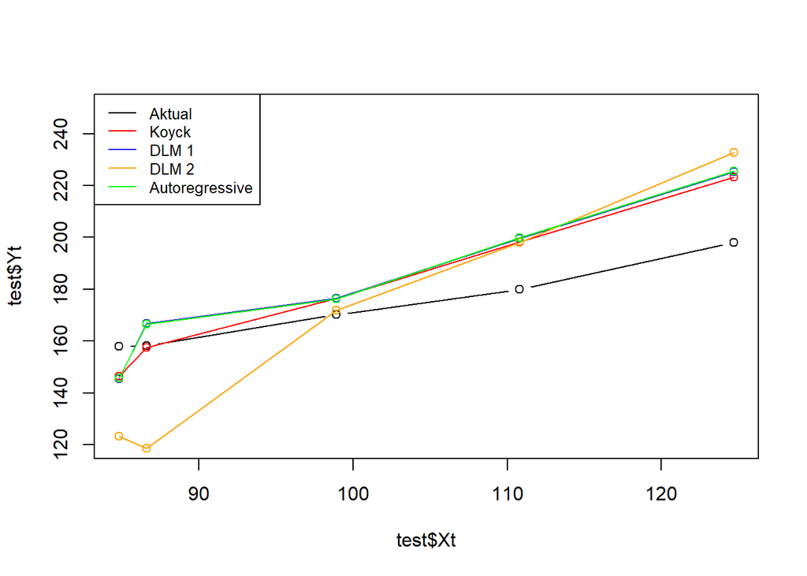

```r
par(mfrow=c(1,1))  # atur layout grafik tunggal

# plot data aktual
plot(test$Xt, test$Yt, type="b", col="black", ylim=c(120,250))

# tambahkan garis ramalan dari masing-masing model
points(test$Xt, fore.koyck$forecasts, col="red");   lines(test$Xt, fore.koyck$forecasts, col="red")
points(test$Xt, fore.dlm$forecasts, col="blue");    lines(test$Xt, fore.dlm$forecasts, col="blue")
points(test$Xt, fore.dlm2$forecasts, col="orange"); lines(test$Xt, fore.dlm2$forecasts, col="orange")
points(test$Xt, fore.ardl$forecasts, col="green");  lines(test$Xt, fore.ardl$forecasts, col="green")

# legenda model
legend("topleft",
       c("Aktual", "Koyck","DLM 1","DLM 2", "Autoregressive"),
       lty=1, col=c("black","red","blue","orange","green"), cex=0.8)
```

Berdasarkan plot perbandingan, terlihat bahwa semua model mampu mengikuti tren data aktual, meskipun dengan tingkat kedekatan yang berbeda. Model DLM 1 (biru) dan Autoregressive (hijau) cukup konsisten mendekati data aktual, sementara DLM 2 (oranye) tampak menyimpang pada awal periode sebelum kembali mendekati tren. Model Koyck (merah) terlihat paling mendekati garis data aktual secara keseluruhan.

## Pengayaan (Regresi Berganda)

### Data

```r
data(M1Germany)
data1 = M1Germany[1:144,]
data1
```

```
##            logm1 logprice   loggnp interest
## 1960 Q1 7.947090 3.403827 8.309448    0.062
## 1960 Q2 7.996191 3.380212 8.387236    0.064
## 1960 Q3 7.949908 3.436211 8.465361    0.064
## 1960 Q4 8.030746 3.419888 8.477333    0.062
## 1961 Q1 7.951792 3.449861 8.374404    0.060
## 1961 Q2 8.020040 3.427157 8.420854    0.057
## 1961 Q3 8.002081 3.478868 8.482004    0.060
## 1961 Q4 8.090023 3.473332 8.488274    0.060
## 1962 Q1 8.006645 3.494354 8.387732    0.058
## 1962 Q2 8.071870 3.470630 8.461327    0.060
## 1962 Q3 8.050562 3.514109 8.525332    0.061
## 1962 Q4 8.122130 3.505587 8.522898    0.062
## 1963 Q1 8.022497 3.535145 8.363411    0.061
## 1963 Q2 8.100153 3.505047 8.478836    0.061
```

[output cut: 130 more lines]

### DLM

```r
#Run the search over finite DLMs according to AIC values
finiteDLMauto(formula = logprice ~ interest+logm1,
              data = data.frame(data1),
              q.min = 1, q.max = 5,
              model.type = "dlm",
              error.type = "AIC", trace = FALSE)
```

```
##   q - k    MASE       AIC       BIC   GMRAE    MBRAE R.Adj.Sq Ljung-Box
## 5     5 1.77163 -463.1393 -422.0566 1.43662 -1.60494  0.98836         0
```

Fungsi akan mencoba model dengan lag minimal q=1 hingga maksimal q=5. Dari hasil, model terbaik yang ditemukan menggunakan lag q=5 dengan nilai AIC = -463.1393.

```r
# Model dengan q = 5 (lag sampai periode ke-5)
model.dlmberganda = dlm(formula = logprice ~ interest + logm1,
                        data = data.frame(data1), q = 5)
summary(model.dlmberganda)
```

```
##
## Call:
## lm(formula = as.formula(model.formula), data = design)
##
## Residuals:
##       Min        1Q    Median        3Q       Max
## -0.095761 -0.028610 -0.000012  0.029496  0.102597
##
## Coefficients:
##             Estimate Std. Error t value Pr(>|t|)
## (Intercept) -7.81759    0.11384 -68.669  < 2e-16 ***
## interest.t  -1.75616    0.80358  -2.185 0.030707 *
## interest.1   1.38935    1.22707   1.132 0.259679
## interest.2   0.40776    1.23726   0.330 0.742273
## interest.3   1.23130    1.20752   1.020 0.309830
## interest.4  -0.08718    1.20869  -0.072 0.942616
## interest.5   3.06850    0.89380   3.433 0.000808 ***
## logm1.t      0.43219    0.20876   2.070 0.040474 *
## logm1.1      0.42190    0.19807   2.130 0.035109 *
## logm1.2      0.20943    0.12883   1.626 0.106532
## logm1.3      0.22053    0.13011   1.695 0.092567 .
## logm1.4      0.05513    0.21457   0.257 0.797633
## logm1.5      0.03042    0.19192   0.159 0.874296
## ---
## Signif. codes:  0 '***' 0.001 '**' 0.01 '*' 0.05 '.' 0.1 ' ' 1
##
## Residual standard error: 0.04343 on 126 degrees of freedom
## Multiple R-squared:  0.9894, Adjusted R-squared:  0.9884
## F-statistic: 977.9 on 12 and 126 DF,  p-value: < 2.2e-16
##
## AIC and BIC values for the model:
##         AIC       BIC
## 1 -463.1393 -422.0566
```

```r
# Model dengan q = 1 (lag sampai periode ke-1)
model.dlmberganda2 = dlm(formula = logprice ~ interest + logm1,
                         data = data.frame(data1), q = 1)
summary(model.dlmberganda2)
```

```
##
## Call:
## lm(formula = as.formula(model.formula), data = design)
##
## Residuals:
##       Min        1Q    Median        3Q       Max
## -0.134002 -0.044697  0.006407  0.036962  0.113063
##
## Coefficients:
##             Estimate Std. Error t value Pr(>|t|)
## (Intercept) -7.77917    0.13299 -58.492  < 2e-16 ***
## interest.t  -3.22103    0.94184  -3.420 0.000824 ***
## interest.1   6.52775    0.94501   6.908 1.66e-10 ***
## logm1.t      0.73918    0.08419   8.780 5.61e-15 ***
## logm1.1      0.63330    0.08429   7.513 6.55e-12 ***
## ---
## Signif. codes:  0 '***' 0.001 '**' 0.01 '*' 0.05 '.' 0.1 ' ' 1
##
## Residual standard error: 0.05443 on 138 degrees of freedom
## Multiple R-squared:  0.9832, Adjusted R-squared:  0.9828
## F-statistic:  2025 on 4 and 138 DF,  p-value: < 2.2e-16
##
## AIC and BIC values for the model:
##         AIC       BIC
## 1 -419.7575 -401.9805
```

### ARDL(p,q)

#### Contoh: ARDL(2,3)

Untuk p = 2 dan q = 3, persamaannya adalah:

$$Y_t = \alpha + \phi_1 Y_{t-1} + \phi_2 Y_{t-2} +
\beta_0 X_t + \beta_1 X_{t-1} + \beta_2 X_{t-2} + \beta_3 X_{t-3}
+ \varepsilon_t$$

- **p** = orde lag untuk variabel dependen (Y).
- **q** = orde lag untuk variabel independen (X).

```r
#Mencari orde lag optimum model ARDL
ardlBoundOrders(data = data1 , formula = logprice ~ interest + logm1,
                ic="AIC")
```

```
## $p
##    interest logm1
## 65        0     4
##
## $q
## [1] 4
##
## $Stat.table
##            q = 1     q = 2     q = 3     q = 4     q = 5     q = 6     q = 7
## p = 1  -760.1786 -757.9195 -846.8342 -975.2079 -965.7536 -958.9072 -956.7315
## p = 2  -760.0433 -759.3090 -843.6247 -971.2514 -961.7929 -955.2809 -953.4890
## p = 3  -753.7746 -753.7746 -841.2485 -970.4543 -961.4343 -953.7173 -950.0412
## p = 4  -829.8076 -832.6436 -832.6436 -971.0837 -962.1804 -955.0429 -953.4667
## p = 5  -749.4144 -753.2292 -962.9290 -962.9290 -961.7063 -954.3406 -951.7660
## p = 6  -742.2103 -742.9945 -891.6195 -952.3771 -952.3771 -952.2461 -950.1105
```

[output cut: 302 more lines]

berdasarkan tabel 3, kombinasi terbaik adalah p = 1 &q=4

```r
model.ardlDlmberganda = ardlDlm(formula = logprice ~ interest + logm1,
                        data = data.frame(data1) , p = 4 , q = 1)
#Untuk fungsi ardlDlm() → notasinya terbalik.
#p = lag X & q = lag Y
summary(model.ardlDlmberganda)
```

```
##
## Time series regression with "ts" data:
## Start = 5, End = 144
##
## Call:
## dynlm(formula = as.formula(model.text), data = data)
##
## Residuals:
##       Min        1Q    Median        3Q       Max
## -0.042843 -0.010058  0.000608  0.010383  0.041257
##
## Coefficients:
##             Estimate Std. Error t value Pr(>|t|)
## (Intercept) -0.63112    0.27547  -2.291  0.02359 *
## interest.t  -0.52613    0.33072  -1.591  0.11411
## interest.1   1.32204    0.50318   2.627  0.00966 **
## interest.2  -0.22306    0.49160  -0.454  0.65079
## interest.3  -0.38347    0.49499  -0.775  0.43994
## interest.4   0.29294    0.37021   0.791  0.43024
## logm1.t      0.21005    0.06791   3.093  0.00243 **
## logm1.1      0.02775    0.05453   0.509  0.61167
## logm1.2     -0.22723    0.05499  -4.132 6.45e-05 ***
## logm1.3      0.03204    0.05174   0.619  0.53687
## logm1.4      0.06950    0.06554   1.060  0.29094
## logprice.1   0.91533    0.03459  26.461  < 2e-16 ***
## ---
## Signif. codes:  0 '***' 0.001 '**' 0.01 '*' 0.05 '.' 0.1 ' ' 1
##
## Residual standard error: 0.01787 on 128 degrees of freedom
## Multiple R-squared:  0.9982, Adjusted R-squared:  0.9981
## F-statistic:  6496 on 11 and 128 DF,  p-value: < 2.2e-16
```

```r
#model p interest 0 p logm1 4
rem.p = list(interest = c(1,2,3,4))
remove = list(p = rem.p)
model.ardlDlmberganda2 = ardlDlm(formula = logprice ~ interest + logm1,
                        data = data.frame(data1) , p = 4 , q = 1 ,
                        remove = remove)
summary(model.ardlDlmberganda2)
```

```
##
## Time series regression with "ts" data:
## Start = 5, End = 144
##
## Call:
## dynlm(formula = as.formula(model.text), data = data)
##
## Residuals:
##      Min       1Q   Median       3Q      Max
## -0.04490 -0.01236  0.00241  0.01181  0.03639
##
## Coefficients:
##             Estimate Std. Error t value Pr(>|t|)
## (Intercept) -0.40668    0.19949  -2.039  0.04349 *
## interest.t   0.31257    0.15653   1.997  0.04790 *
## logm1.t      0.17890    0.06459   2.770  0.00642 **
## logm1.1      0.01712    0.05453   0.314  0.75400
## logm1.2     -0.25041    0.05343  -4.687 6.83e-06 ***
## logm1.3      0.02177    0.05263   0.414  0.67979
## logm1.4      0.10613    0.06132   1.731  0.08587 .
## logprice.1   0.94369    0.02460  38.364  < 2e-16 ***
## ---
## Signif. codes:  0 '***' 0.001 '**' 0.01 '*' 0.05 '.' 0.1 ' ' 1
##
## Residual standard error: 0.01832 on 132 degrees of freedom
## Multiple R-squared:  0.9981, Adjusted R-squared:  0.998
## F-statistic:  9706 on 7 and 132 DF,  p-value: < 2.2e-16
```

Proses selanjutnya sama dengan pemodelan menggunakan peubah tunggal.

## Tugas Individu

intruksi tugas

1. Gunakan dataset kualitas udara yg ada di github :
2. Tetapkan AQI sebagai variabel dependen (Y), lalu pilih satu variabel polutan (CO, NO₂, O₃, PM10, PM2.5, atau SO₂) sebagai variabel independen (X).
3. Terapkan metode regresi dengan peubah lag yang sudah dipelajari
4. Bandingkan kinerja model, kemudian tentukan model terbaik menggunakan metrik akurasi.
5. Upload data dan tugas per individu ke GitHub pada folder Pertemuan-3 dengan format HTML bernama: Tugas-Pertemuan-3.html dan rmd